# Binge Drinking Prediction

This code is designed to predict whether or not someone is a binge drinker, based on responses to survey questions.

```r
knitr::opts_chunk$set(echo = TRUE)
# Remove all previous objects from the data set
rm(list=ls(all=TRUE))
options(scipen=999)

# Load the tidyverse
library(tidyverse)
library(stringr)

# Load e1071 for the SVM (Support Vector Machine) functions
library(e1071)

# Load the library nnet, which will allow us to run multinom, which is a form of logistic regression different than glm.
library(nnet)

# Load cwhmisc and two dependencies.
library(cwhmisc)
library(lattice)
library(grid)
library(rpart)

# Librarys for confustion matrix for confirming svm and lr models
library(caret)
```

```r
library(heuristica)

# For plotting decision trees
library(rpart.plot)
library(partykit) #GRACE CHECK FINAL
library(randomForest) #GRACE CHECK FINAL
# This is for testing the accuracy of our logistic regression
library(pscl)
```

# Read in the 2015 BRFSS data

```r
Y2015 <- read_csv("data/2015.csv", col_names= TRUE)
```

Create a subset of the data that only contains data that only contains computed variables by finding columns with underscores at the start https://www.cdc.gov/brfss/annual_data/2015/pdf/codebook15_llcp.pdf. NOTE: Updated this to include calculated variables that end with underscores, too.

```r
data <- Y2015 %>%
  select(starts_with("_"), ends_with("_"))
```

Then rename the columns to get rid of the stupid underscores that are screwing stuff up and make them lowercase.

```r
names(data) <- names(data) %>%
  tolower() %>%
  str_replace_all("_", "")
```

Read in FIPS Code data set to match state codes with state names

```r
fips<-read_csv("data/fipscodes.csv", col_types = cols(STATE_FIPS = col_double()))
```

Read in 2015 ACS survey data which has selected economic characteristics as percentages like health coverage, unemployment, poverty, food stamps, people making less than 10K, people making more than 200K

```r
census <- read_csv("data/census.csv")
```

Join fips code with master BRFSS data, to get state names, then join to the census data

```r
data <- left_join(data, fips, by = c("state" = "STATE_FIPS"))
data <- left_join(data, census, by = c("STATE_NAME" = "state_name"))
data <- data %>%
  select(-c(STUSAB,STATE_NAME,STATENS,state.y))
```

First, filter only rows that contain binge drinking 1 (no), 2 (yes) (removing the 9 and other values). Then remove five columns that have lots of NA values to get a workable dataset. And then omit any rows with NA values.

```r
binge <- data %>%
  filter(rfbing5 == c(1,2)) %>%
  select(-cllcpwt,-crace1,-cprace,-flshot6,-pneumo2) %>%
  na.omit()
```

Convert the binge data to 1 and 0

```r
binge$rfbing5[binge$rfbing5 == 1] <- 5
binge$rfbing5[binge$rfbing5 == 2] <- 1
binge$rfbing5[binge$rfbing5 == 5] <- 0
```

Create a table to count NAs by column to get a nice list of most problematic columns, which helped me figure out what to take out in the columns above. Don’t actually need to run this again, but here in case we need it again.

```r
na_count <-sapply(binge, function(y) sum(length(which(is.na(y)))))
na_count <- data.frame(na_count)
```

Let’s do some feature engineering on the handful of variables that are non categorical in our data set.

```r
#frutsum- base 10
binge$log10frutsum<-log10(binge$frutsum)

#vegsum- base 10
binge$log10frutsum<-log10(binge$vegesum)

#frutsum- base 2
binge$log2frutsum<-log2(binge$frutsum)

#vegsum- base 2
binge$log2frutsum<-log2(binge$vegesum)

#do you even food pyramid bro
binge$highVeg<- (binge$log2frutsum * binge$log2frutsum)

#mixed drinks
binge$mixedDrinks <- scale(binge$drnkwek*binge$rfdrhv5)

# Take the log to normalize all of our census variables
binge$log2unemployment <- log2(binge$unemployment)
binge$log2less_10K <- log2(binge$less_10K)
binge$log2more_200k <- log2(binge$more_200k)
binge$log2foodstamp <- log2(binge$foodstamp)
binge$log2healthinsurance <- log2(binge$healthinsurance)
binge$log2poverty <- log2(binge$poverty)

# Create an inequality index by dividing more than 200K percentage by less than 10K percentage,with higher number meaning more unequal.
binge <- binge %>%
  mutate(inequality = more_200k/less_10K)
```

Now let’s split our “full” data set into a training slice and a testing slice (I know, even though we have a separate test set). 1/5 in testset and 4/5 in trainset.

```r
index <- 1:nrow(binge)
testindex <- sample(index, trunc(length(index)/5))
testset <- binge[testindex,]
trainset <- binge[-testindex,]
```

Write out our train and test sets

```r
write.csv(trainset, file="train.csv")
write.csv(testset, file="test.csv")
```

Define my evaluation functions

```r
record_performance <- function( model_type, df, name, model, test) {
  # if-else statement to change pred variable depending on model type
  if (model_type=="svm"){
    pred <- predict(model, test)
  }
  else if (model_type=="tree"){
    pred <- predict(model, test,type="class")
  }
  else if (model_type=="ctree"){
    pred <- predict(model, test)
  }
  else if (model_type=="logit"){
    pred <- predict(model, test,type="class") #we may need to store this as type="response"
  }
  else if (model_type=="ensemble"){
    pred <- predict(model, test) #we may need to store this as type="response"
  }
  # create a table with the prediction from the model and the actual value in the test data
  table <- table(pred = pred, true=testset$rfbing5)
  # calculate the "score" the degree to which the values in our prediction agree (classAgreement) with values in the test data.  Then add them to a table we create with multiple model predictions.
  df <- rbind(df, data.frame(model=c(name), score=c(classAgreement(table)$diag)))
  return(df)
}
```

First let’s check for statistically signficant variables, and only consider those variables in our model by printing out a coefficient table

```r
test_glm<-glm(rfbing5 ~ ., data=trainset)
print(summary(test_glm))
```

```
##
## Call:
## glm(formula = rfbing5 ~ ., data = trainset)
##
## Deviance Residuals:
##     Min       1Q   Median       3Q      Max
## -3.5131  -0.1283  -0.0503   0.0193   1.0608
##
## Coefficients: (17 not defined because of singularities)
##                                  Estimate            Std. Error t value
## (Intercept)         -702873299.7375290394 3102941991.8535466194  -0.227
## state.x                     -0.6004379438          0.4556002767  -1.318
## psu                          0.0000006525          0.0000006170   1.058
## ststr                        0.0000600027          0.0000455554   1.317
## strwt                       -0.0000824555          0.0000404119  -2.040
## rawrake                     -0.0095132688          0.0030717946  -3.097
## wt2rake                      0.0000647698          0.0000390696   1.658
## chispnc2.0                   0.0064232287          0.0140337961   0.458
## chispnc9.0                   0.0082929135          0.0143472198   0.578
## dualuse                     -0.0621152924          0.0451945346  -1.374
## dualcor                      0.0086439184          0.0151037710   0.572
## llcpwt                       0.0000008306          0.0000036961   0.225
## rfhlth                       0.0003966799          0.0041600806   0.095
## hcvu651                     -0.0033648491          0.0057675262  -0.583
## rfhype5                      0.0070954190          0.0031837542   2.229
## cholchk                      0.0023526431          0.0023857737   0.986
## rfchol                       0.0010057306          0.0022273849   0.452
## michd                       -0.0013106506          0.0064328424  -0.204
## ltasth1                     -0.0030391799          0.0057096323  -0.532
## casthm1                     -0.0070351294          0.0043033904  -1.635
## asthms1                      0.0078368590          0.0027724534   2.827
## drdxar1                      0.0001849652          0.0074979471   0.025
## prace1                       0.0054348527          0.0050748313   1.071
## mrace1                      -0.0061035714          0.0050919027  -1.199
## hispanc                      0.3278112703          0.1514883784   2.164
## race                        -0.0044415302          0.0107959369  -0.411
## raceg21                     -0.0850279355          0.0351443423  -2.419
## racegr3                      0.1536676179          0.0721915512   2.129
## raceg1                      -0.0754207999          0.0334752514  -2.253
## ageg5yr                      0.0084919359          0.0056681498   1.498
```

[output cut: 194 more lines]

```
## log2more_200k                   0.009112 **
## log2foodstamp                   0.018034 *
## log2healthinsurance             0.350238
## log2poverty                     0.130827
## inequality                      0.326800
## ---
## Signif. codes:  0 '***' 0.001 '**' 0.01 '*' 0.05 '.' 0.1 ' ' 1
##
## (Dispersion parameter for gaussian family taken to be 0.07626106)
##
##     Null deviance: 3105.1  on 29696  degrees of freedom
## Residual deviance: 2257.3  on 29600  degrees of freedom
## AIC: 7947.3
##
## Number of Fisher Scoring iterations: 2
```

```r
test_glm <-glm(rfbing5 ~ rfhype5 + asthms1 +  ageg + rfbmi5 + educag + smoker3 + rfsmok3 + drnkwek + rfdrhv5 + frutsum + frtlt1 + veg23 + minac11 + pastrng + rfseat2 + rfseat3 + drocdy3 + ftjuda1 + padur1 + padur2 + foodstamp, data=trainset)
print(summary(test_glm))
```

```
##
## Call:
## glm(formula = rfbing5 ~ rfhype5 + asthms1 + ageg + rfbmi5 + educag +
##     smoker3 + rfsmok3 + drnkwek + rfdrhv5 + frutsum + frtlt1 +
##     veg23 + minac11 + pastrng + rfseat2 + rfseat3 + drocdy3 +
##     ftjuda1 + padur1 + padur2 + foodstamp, data = trainset)
##
## Deviance Residuals:
##      Min        1Q    Median        3Q       Max
## -0.82429  -0.13753  -0.05078   0.02122   1.47027
##
## Coefficients:
##                  Estimate    Std. Error t value             Pr(>|t|)
## (Intercept)  0.2302447588  0.1454033073   1.583             0.113320
## rfhype5      0.0067920722  0.0031840524   2.133             0.032920 *
## asthms1      0.0081717668  0.0023201030   3.522             0.000429 ***
## ageg        -0.0558422072  0.0013786576 -40.505 < 0.0000000000000002 ***
## rfbmi5       0.0351382996  0.0035227376   9.975 < 0.0000000000000002 ***
## educag      -0.0063997362  0.0020172009  -3.173             0.001512 **
## smoker3     -0.0248718264  0.0019586222 -12.699 < 0.0000000000000002 ***
## rfsmok3      0.0186454024  0.0027952229   6.670      0.0000000000259 ***
## drnkwek     -0.0000254425  0.0000007398 -34.389 < 0.0000000000000002 ***
## rfdrhv5      0.3531131773  0.0085508704  41.296 < 0.0000000000000002 ***
## frutsum     -0.0000987834  0.0000193437  -5.107      0.0000003297890 ***
## frtlt1       0.0256029253  0.0045158115   5.670      0.0000000144444 ***
## veg23       -0.3069386873  0.1428612095  -2.149             0.031681 *
## minac11     -0.0000219032  0.0000072925  -3.004             0.002671 **
## pastrng     -0.0058825652  0.0034337039  -1.713             0.086689 .
## rfseat2     -0.0226535065  0.0092458245  -2.450             0.014286 *
## rfseat3      0.0419355016  0.0068603357   6.113      0.0000000009915 ***
## drocdy3      0.0028215306  0.0000590123  47.813 < 0.0000000000000002 ***
## ftjuda1      0.0001785392  0.0000358701   4.977      0.0000006481135 ***
## padur1       0.0001653145  0.0000357329   4.626      0.0000037365863 ***
## padur2       0.0001006213  0.0000221223   4.548      0.0000054267639 ***
## foodstamp   -0.0015273633  0.0005333322  -2.864             0.004189 **
## ---
## Signif. codes:  0 '***' 0.001 '**' 0.01 '*' 0.05 '.' 0.1 ' ' 1
##
## (Dispersion parameter for gaussian family taken to be 0.08062987)
##
##     Null deviance: 3105.1  on 29696  degrees of freedom
## Residual deviance: 2392.7  on 29675  degrees of freedom
## AIC: 9526.8
##
## Number of Fisher Scoring iterations: 2
```

Get the most frequent baseline, tells us how many people are not binge drinkers. Any model we build needs to do better than this baseline. Let’s add a bunch of different versions of the model and test accuracy in a data frame

```r
models.mfc_baseline <- sum(trainset$rfbing5 == 0) / nrow(trainset)
models.results <- data.frame(model=c("MFC"), score=c(models.mfc_baseline))

# Now let's create a logistic regression model in which we add all variables
models.results <- record_performance("logit", models.results, "all", multinom(rfbing5 ~ ., data=trainset),testset)
```

Now let’s create a logistic regression model in which we add all variables except for drnkwek

```r
models.results <- record_performance("logit", models.results, "all no drnkwek", multinom(rfbing5 ~ . -drnkwek, data=trainset),testset)
```

Now let’s create a logistic regression model in which we add all variables except for rfdrhv5

```r
models.results <- record_performance("logit", models.results, "all no rfdrhv5", multinom(rfbing5 ~ . -rfdrhv5, data=trainset),testset)
```

Now let’s create a logistic regression model in which we add all variables except for no drnkwek or rfdrhv5

```r
models.results <- record_performance("logit", models.results, "all no drnkwek or rfdrhv5", multinom(rfbing5 ~ . -drnkwek -rfdrhv5 , data=trainset),testset)
```

Here is a model with all of our significant variables in our earlier glm

```r
models.results <- record_performance("logit", models.results, "all sig variables", multinom(rfbing5 ~ rfhype5 + asthms1 +  ageg + rfbmi5 + educag + smoker3 + rfsmok3 + drnkwek + rfdrhv5 + frutsum + frtlt1 + veg23 + minac11 + pastrng + rfseat2 + rfseat3 + drocdy3 + ftjuda1 + padur1 + padur2 + foodstamp, data=trainset),testset)
```

Here is all of our significant variables in earlier glm except drnkwek and rfdrhv5

```r
models.results <- record_performance("logit", models.results, "all sig variables except drinking", multinom(rfbing5 ~ rfhype5 + asthms1 +  ageg + rfbmi5 + educag + smoker3 + rfsmok3 + frutsum + frtlt1 + veg23 + minac11 + pastrng + rfseat2 + rfseat3 + drocdy3 + ftjuda1 + padur1 + padur2 + foodstamp, data=trainset),testset)
```

Print out the table of models.results

```r
models.results
```

```
##                               model     score
## 1                               MFC 0.8813685
## 2                               all 0.9011315
## 3                    all no drnkwek 0.8956088
## 4                    all no rfdrhv5 0.8876616
## 5         all no drnkwek or rfdrhv5 0.8886045
## 6                 all sig variables 0.8935884
## 7 all sig variables except drinking 0.8904903
```

Now let’s test SVM Models For a full breakdown of tests on svm models, see 737-SVM-Code.r Listed here is only the best performing of the SVM Models

```r
best_svm <- svm(rfbing5 ~ hcvu651 + raceg21 + age80 + rfbmi5 + smoker3 + rfsmok3 + drnkwek + rfdrhv5 + frtlt1 + pa300r2 + lmtact1 + rfseat3, data=trainset)
```

Set the baseline and prep a dataframe for comparison, then print it out

```r
svmmodels.mfc_baseline <- sum(trainset$rfbing5 == 0) / nrow(trainset)
svmmodels.results <- data.frame(model=c("MFC"), score=c(svmmodels.mfc_baseline))

svmmodels.results <- record_performance("svm", svmmodels.results, "svm all sig var", best_svm,testset)

svmmodels.results
```

```
##             model        score
## 1             MFC 0.8813684884
## 2 svm all sig var 0.0001346983
```

Now let’s test Decision Tree Models

```r
#Kick the tires
trainset$rfbing5 <- as.character(trainset$rfbing5)
trainset$rfbing5 <- as.factor(trainset$rfbing5)
```

Create a decision tree accounting for all variables

```r
treeAllModel <-  rpart(rfbing5 ~ . , data=trainset, method="class")
# Print out a summary
summary(treeAllModel)
```

```
## Call:
## rpart(formula = rfbing5 ~ ., data = trainset, method = "class")
##   n= 29697
##
##           CP nsplit rel error    xerror       xstd
## 1 0.09395402      0 1.0000000 1.0000000 0.01581694
## 2 0.03491343      2 0.8120920 0.8242975 0.01452914
## 3 0.01107011      3 0.7771785 0.7933579 0.01428283
## 4 0.01000000      4 0.7661084 0.7706500 0.01409786
##
## Variable importance
##     drnkwek mixedDrinks     rfdrhv5     drocdy3        fc60      maxvo2
##          30          30          16           4           4           4
##       age80     ageg5yr        ageg     age65yr
##           4           4           3           3
##
## Node number 1: 29697 observations,    complexity param=0.09395402
##   predicted class=0  expected loss=0.1186315  P(node) =1
##     class counts: 26174  3523
##    probabilities: 0.881 0.119
##   left son=2 (26369 obs) right son=3 (3328 obs)
##   Primary splits:
##       drnkwek     < 723.5       to the left,  improve=1285.5430, (0 missing)
##       mixedDrinks < -0.05409557 to the left,  improve=1285.5430, (0 missing)
##       rfdrhv5     < 1.5         to the left,  improve= 913.9903, (0 missing)
##       drocdy3     < 15.5        to the left,  improve= 755.2243, (0 missing)
##       maxvo2      < 2695.5      to the left,  improve= 211.7693, (0 missing)
##   Surrogate splits:
##       mixedDrinks  < -0.05409557 to the left,  agree=1.000, adj=1.000, (0 split)
##       rfdrhv5      < 1.5         to the left,  agree=0.950, adj=0.551, (0 split)
##       drocdy3      < 51.5        to the left,  agree=0.903, adj=0.138, (0 split)
##       vegesum      < 2751.5      to the left,  agree=0.888, adj=0.001, (0 split)
##       log10frutsum < 3.43891     to the left,  agree=0.888, adj=0.001, (0 split)
##
## Node number 2: 26369 observations
##   predicted class=0  expected loss=0.06636581  P(node) =0.8879348
##     class counts: 24619  1750
##    probabilities: 0.934 0.066
##
## Node number 3: 3328 observations,    complexity param=0.09395402
```

[output cut: 56 more lines]

```
##   Surrogate splits:
##       rfdrhv5     < 5.5         to the right, agree=1.000, adj=1.000, (0 split)
##       mixedDrinks < 9.083924    to the right, agree=1.000, adj=1.000, (0 split)
##       drocdy3     < 25          to the left,  agree=0.951, adj=0.627, (0 split)
##       lmtwrk1     < 6           to the right, agree=0.870, adj=0.017, (0 split)
##
## Node number 26: 59 observations
##   predicted class=0  expected loss=0.1694915  P(node) =0.001986733
##     class counts:    49    10
##    probabilities: 0.831 0.169
##
## Node number 27: 388 observations
##   predicted class=1  expected loss=0.2912371  P(node) =0.01306529
##     class counts:   113   275
##    probabilities: 0.291 0.709
```

Important variables for treeAllModel: drnkwek + mixedDrinks + rfdrhv5 + fc60 + maxvo2 + age80+ ageg+ageg5yr+age65yr

Set baseline for tree model, predict various versions of the tree model

```r
treemodels.mfc_baseline <- sum(trainset$rfbing5 == 0) / nrow(trainset)
treemodels.results <- data.frame(model=c("MFC"), score=c(treemodels.mfc_baseline))

# Now let's create a tree regression model in which we add all variables
treemodels.results <- record_performance("tree", treemodels.results, "treeallVar", rpart(rfbing5 ~ ., data=trainset, method="class"),testset)

# Now let's create a tree regression model in which we add variables important in prior runs
treemodels.results <- record_performance("tree", treemodels.results, "treeForestImpVar", rpart(rfbing5 ~ drnkwek + rfdrhv5 + age80+ ageg+ageg5yr+age65yr+hcvu651+chldcnt+chispnc, data=trainset, method="class"),testset)

# Now let's create a tree regression model in which we add variables important in prior runs
treemodels.results <- record_performance("tree", treemodels.results, "treeAllImpVar", rpart(rfbing5 ~ drnkwek + mixedDrinks + rfdrhv5 + fc60 + maxvo2 + age80+ ageg+ageg5yr+age65yr , data=trainset, method="class"),testset)

# Try it without drinking variables using old variables better than baseline, but not by much
treemodels.results <- record_performance("tree", treemodels.results, "treeForestImpVar_noDrink", rpart(rfbing5 ~ age80+ ageg+ageg5yr+age65yr+hcvu651+chldcnt+chispnc, data=trainset, method="class"),testset)

# Now let's create a tree regression model in which we use new imp variables minus drinking variables
treemodels.results <- record_performance("tree", treemodels.results, "treeAllImpVar_noDrink", rpart(rfbing5 ~ fc60 + maxvo2 + age80+ ageg+ageg5yr+age65yr , data=trainset, method="class"),testset)

treemodels.results
```

```
##                      model     score
## 1                      MFC 0.8813685
## 2               treeallVar 0.9027478
## 3         treeForestImpVar 0.9015356
## 4            treeAllImpVar 0.9027478
## 5 treeForestImpVar_noDrink 0.8807920
## 6    treeAllImpVar_noDrink 0.8807920
```

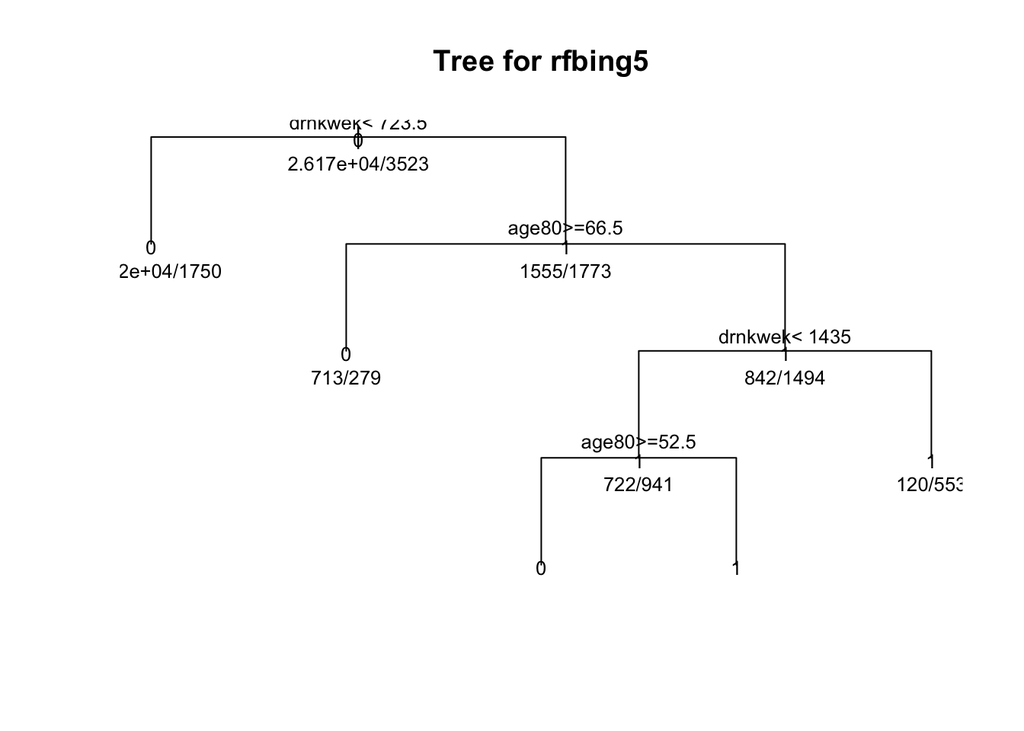

```r
fit <- rpart(rfbing5 ~ drnkwek + rfdrhv5 + age80 + ageg+ageg5yr+age65yr+hcvu651+chldcnt+chispnc, method="class", data=trainset)
plot(fit, uniform=TRUE,
     main="Tree for rfbing5")
text(fit, use.n=TRUE, all=TRUE, cex=.8)
```

```r
post(fit, file = "tree.ps",
     title = "Tree for rfbing5")
```

Create Conditional Inference Tree (Doesn’t add anything, so leave out of ensemble

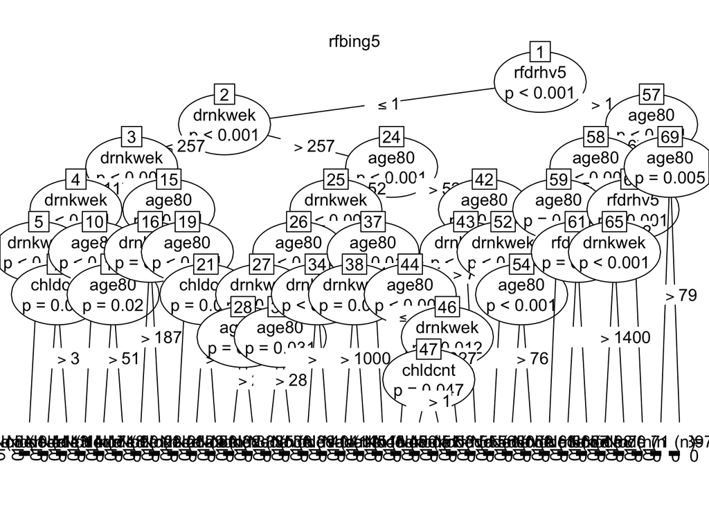

```r
#library(partykit)
fit2 <- ctree(rfbing5 ~ drnkwek + rfdrhv5 + age80 + chldcnt ,  data=trainset)
plot(fit2, main="rfbing5")
```

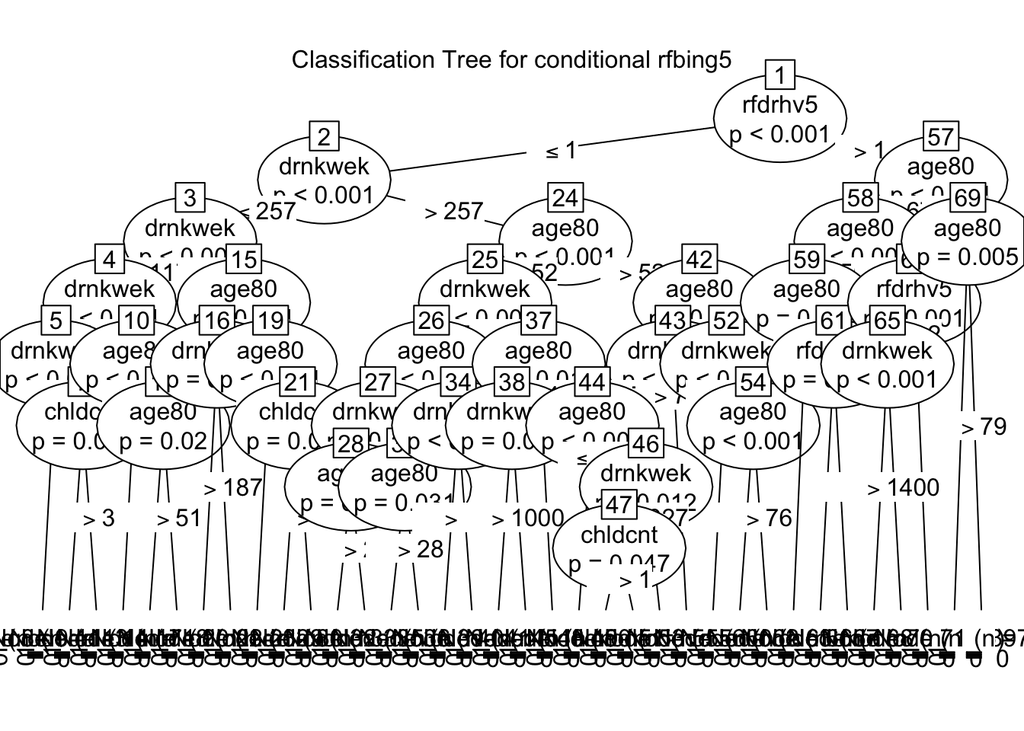

```r
plot(fit2, uniform=TRUE, main="Classification Tree for conditional rfbing5")
```

```r
treemodels.results <- record_performance("ctree", treemodels.results, "c", ctree(rfbing5 ~ drnkwek + rfdrhv5 + age80 + ageg5yr + chldcnt,  data=trainset),testset)
#Try again with top 10 random forest predictors (oh man it just gets worse?)
treemodels.results <- record_performance("ctree", treemodels.results, "c2", ctree(rfbing5 ~ drnkwek+    drocdy3+    rfdrhv5+    fc60+   maxvo2+ age80+  bmi5,  data=trainset),testset)
```

Let’s run several Random Forests

```r
#trainset$rfbing5 <- as.character(trainset$rfbing5)
#trainset$rfbing5 <- as.factor(trainset$rfbing5)
#library(randomForest)
treemodels.results <- record_performance("tree", treemodels.results, "forest_All", randomForest(rfbing5 ~ ., model='class',  data=trainset),testset)
treeAllFit<-randomForest(rfbing5 ~ ., model="class",  data=trainset) #this one takes about 20minutes
importance(treeAllFit)
```

```
##                     MeanDecreaseGini
## state.x                  46.96745729
## psu                     103.58596081
## ststr                    74.66727822
## strwt                    77.45112837
## rawrake                  23.54431043
## wt2rake                  83.01470535
## chispnc                  14.07082549
## dualuse                   9.93034398
## dualcor                  60.34707523
## llcpwt                   94.54872109
## rfhlth                    6.30972511
## hcvu651                  27.48765525
## rfhype5                  13.26579361
## cholchk                   8.36691347
## rfchol                   14.08077929
## michd                     5.61357361
## ltasth1                   7.18087805
## casthm1                   6.30365092
## asthms1                  10.36138090
## drdxar1                   9.82556232
## prace1                   11.61492830
## mrace1                   11.71646260
## hispanc                   3.99429766
## race                     11.75515743
## raceg21                   6.37697693
## racegr3                  11.70782092
## raceg1                   12.19537571
## ageg5yr                  79.74024854
## age65yr                  23.76486849
## age80                   126.49563299
## ageg                     46.94096708
## bmi5                    106.60807326
## bmi5cat                  25.81730123
## rfbmi5                   12.84695891
## chldcnt                  26.96951967
## educag                   30.31812332
## incomg                   28.12254697
## smoker3                  49.29112251
## rfsmok3                  18.13963431
```

[output cut: 58 more lines]

```
## more_200k                41.33413548
## foodstamp                45.74580297
## healthinsurance          47.45447993
## poverty                  42.41001179
## log10frutsum             78.41738479
## log2frutsum              79.11732027
## highVeg                  79.45340382
## mixedDrinks             717.30533374
## log2unemployment         40.23209735
## log2less_10K             38.36187489
## log2more_200k            41.73047883
## log2foodstamp            44.92457090
## log2healthinsurance      47.29412673
## log2poverty              41.83325117
## inequality               46.52967834
```

Determine important components- before new/eng. var

```r
fit3 <- randomForest(rfbing5 ~ drnkwek + rfdrhv5 + age80+ ageg+ageg5yr+age65yr+hcvu651+chldcnt+chispnc,   data=trainset)
print(fit3) # view results
```

```
##
## Call:
##  randomForest(formula = rfbing5 ~ drnkwek + rfdrhv5 + age80 +      ageg + ageg5yr + age65yr + hcvu651 + chldcnt + chispnc, data = trainset)
##                Type of random forest: classification
##                      Number of trees: 500
## No. of variables tried at each split: 3
##
##         OOB estimate of  error rate: 8.99%
## Confusion matrix:
##       0    1 class.error
## 0 25545  629  0.02403148
## 1  2042 1481  0.57961964
```